# NSynth Dataset

### Spectral Rolloff Frequency: [librosa.feature.spectral_rolloff](https://librosa.github.io/librosa/generated/librosa.feature.spectral_rolloff.html)

From the function docstring:  
The **roll-off frequency** is defined for each frame as the center frequency for a spectrogram bin such that at least roll_percent (0.85 by default) of the energy of the spectrum in this frame is contained in this bin and the bins below. This can be used to, e.g., approximate the maximum (or minimum) frequency by setting roll_percent to a value close to 1 (or 0).

```python
rolloffs = []
for y_, sr_ in zip(y, sr):
    rolloffs.append(librosa.feature.spectral_rolloff(y=y_, sr=sr_))
```

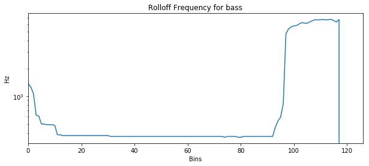

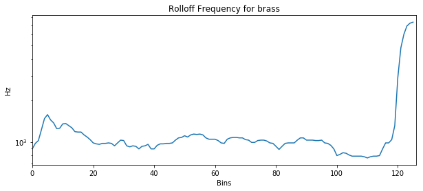

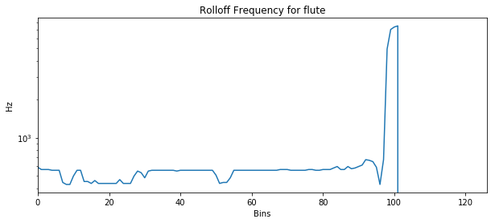

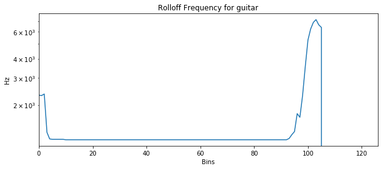

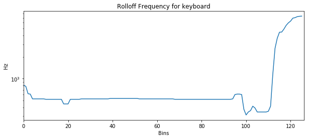

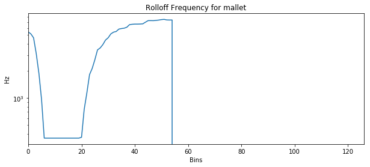

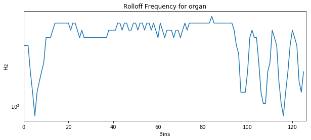

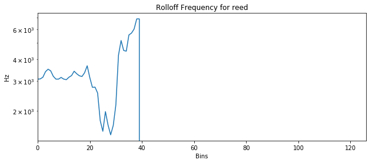

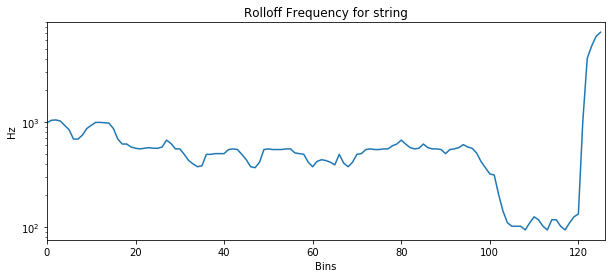

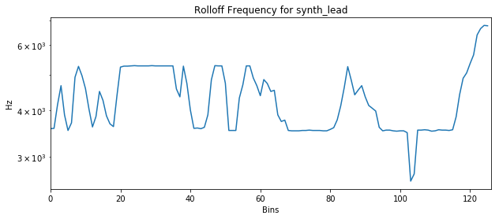

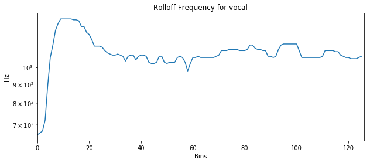

```python
for rolloff, instrument, i in zip(rolloffs,class_names, range(len(class_names))):
    plt.figure(figsize=(10,4))
    plt.semilogy(rolloff.T, label='Rolloff frequency for ' + instrument)
    plt.ylabel('Hz')
    plt.xlim([0, rolloff.shape[-1]])
    plt.xlabel('Bins')
    plt.xticks(np.arange(0,rolloff.shape[-1],20))
    plt.title("Rolloff Frequency for "+ class_names[i])
    plt.savefig('plots/rolloff_freq'+str(class_names[i])+'.png')


plt.show()
```